# dkpol daily compared

Max Odsbjerg Pedersen

2/12/2020

# Using twitter-api - #dkpol as exampel

# Importing data from twitter

Using rtweet function to read in dkpol-tweets.

```r
dkpoltweets <- search_tweets(q = "#dkpol", n = 10000,
                                      lang = "da",
                                      include_rts = FALSE)
```

For more information on what the rtweet-package can do see: https://rtweet.info/

Viewing the first entries to make sure that we have the right thing

```r
head(dkpoltweets)
```

```
## # A tibble: 6 x 90
##   user_id status_id created_at          screen_name text  source
##   <chr>   <chr>     <dttm>              <chr>       <chr> <chr>
## 1 724743… 12294518… 2020-02-17 17:05:49 liberty_da… "@Kl… Tweet…
## 2 724743… 12283920… 2020-02-14 18:54:13 liberty_da… "@st… Tweet…
## 3 724743… 12273661… 2020-02-11 22:57:39 liberty_da… "@Mo… Tweet…
## 4 724743… 12283917… 2020-02-14 18:53:02 liberty_da… "@st… Tweet…
## 5 724743… 12294509… 2020-02-17 17:02:07 liberty_da… "@St… Tweet…
## 6 724743… 12294506… 2020-02-17 17:00:42 liberty_da… "@St… Tweet…
## # … with 84 more variables: display_text_width <dbl>,
## #   reply_to_status_id <chr>, reply_to_user_id <chr>,
## #   reply_to_screen_name <chr>, is_quote <lgl>, is_retweet <lgl>,
## #   favorite_count <int>, retweet_count <int>, quote_count <int>,
## #   reply_count <int>, hashtags <list>, symbols <list>, urls_url <list>,
## #   urls_t.co <list>, urls_expanded_url <list>, media_url <list>,
## #   media_t.co <list>, media_expanded_url <list>, media_type <list>,
## #   ext_media_url <list>, ext_media_t.co <list>,
## #   ext_media_expanded_url <list>, ext_media_type <chr>,
## #   mentions_user_id <list>, mentions_screen_name <list>, lang <chr>,
## #   quoted_status_id <chr>, quoted_text <chr>, quoted_created_at <dttm>,
## #   quoted_source <chr>, quoted_favorite_count <int>,
## #   quoted_retweet_count <int>, quoted_user_id <chr>,
## #   quoted_screen_name <chr>, quoted_name <chr>,
## #   quoted_followers_count <int>, quoted_friends_count <int>,
## #   quoted_statuses_count <int>, quoted_location <chr>,
## #   quoted_description <chr>, quoted_verified <lgl>,
## #   retweet_status_id <chr>, retweet_text <chr>,
## #   retweet_created_at <dttm>, retweet_source <chr>,
## #   retweet_favorite_count <int>, retweet_retweet_count <int>,
## #   retweet_user_id <chr>, retweet_screen_name <chr>, retweet_name <chr>,
## #   retweet_followers_count <int>, retweet_friends_count <int>,
## #   retweet_statuses_count <int>, retweet_location <chr>,
## #   retweet_description <chr>, retweet_verified <lgl>, place_url <chr>,
## #   place_name <chr>, place_full_name <chr>, place_type <chr>,
## #   country <chr>, country_code <chr>, geo_coords <list>,
## #   coords_coords <list>, bbox_coords <list>, status_url <chr>,
## #   name <chr>, location <chr>, description <chr>, url <chr>,
## #   protected <lgl>, followers_count <int>, friends_count <int>,
## #   listed_count <int>, statuses_count <int>, favourites_count <int>,
## #   account_created_at <dttm>, verified <lgl>, profile_url <chr>,
## #   profile_expanded_url <chr>, account_lang <lgl>,
## #   profile_banner_url <chr>, profile_background_url <chr>,
## #   profile_image_url <chr>
```

Seems to be the right thing. But the tweets arent organised after date. Let’s fix that:

```r
dkpoltweets %>%
  arrange(desc(created_at)) -> dkpoltweets
```

```r
dkpoltweets
```

```
## # A tibble: 6,929 x 90
##    user_id status_id created_at          screen_name text  source
##    <chr>   <chr>     <dttm>              <chr>       <chr> <chr>
##  1 724743… 12294518… 2020-02-17 17:05:49 liberty_da… "@Kl… Tweet…
##  2 215749… 12294514… 2020-02-17 17:04:00 janweichar… @Haa… Twitt…
##  3 112095… 12294513… 2020-02-17 17:03:31 A4Arbejdsm… "43.… Twitt…
##  4 749382… 12294511… 2020-02-17 17:02:45 A4Medier    43.0… Echob…
##  5 724743… 12294509… 2020-02-17 17:02:07 liberty_da… "@St… Tweet…
##  6 724743… 12294506… 2020-02-17 17:00:42 liberty_da… "@St… Tweet…
##  7 724743… 12294502… 2020-02-17 16:59:13 liberty_da… "@St… Tweet…
##  8 252477… 12294500… 2020-02-17 16:58:34 berger_bo   "Ska… Twitt…
##  9 724743… 12294498… 2020-02-17 16:57:49 liberty_da… "@St… Tweet…
## 10 571395… 12294495… 2020-02-17 16:56:31 Wehnert     @pon… Twitt…
## # … with 6,919 more rows, and 84 more variables: display_text_width <dbl>,
## #   reply_to_status_id <chr>, reply_to_user_id <chr>,
## #   reply_to_screen_name <chr>, is_quote <lgl>, is_retweet <lgl>,
## #   favorite_count <int>, retweet_count <int>, quote_count <int>,
## #   reply_count <int>, hashtags <list>, symbols <list>, urls_url <list>,
## #   urls_t.co <list>, urls_expanded_url <list>, media_url <list>,
## #   media_t.co <list>, media_expanded_url <list>, media_type <list>,
## #   ext_media_url <list>, ext_media_t.co <list>,
## #   ext_media_expanded_url <list>, ext_media_type <chr>,
## #   mentions_user_id <list>, mentions_screen_name <list>, lang <chr>,
## #   quoted_status_id <chr>, quoted_text <chr>, quoted_created_at <dttm>,
## #   quoted_source <chr>, quoted_favorite_count <int>,
## #   quoted_retweet_count <int>, quoted_user_id <chr>,
## #   quoted_screen_name <chr>, quoted_name <chr>,
## #   quoted_followers_count <int>, quoted_friends_count <int>,
## #   quoted_statuses_count <int>, quoted_location <chr>,
## #   quoted_description <chr>, quoted_verified <lgl>,
## #   retweet_status_id <chr>, retweet_text <chr>,
## #   retweet_created_at <dttm>, retweet_source <chr>,
## #   retweet_favorite_count <int>, retweet_retweet_count <int>,
## #   retweet_user_id <chr>, retweet_screen_name <chr>, retweet_name <chr>,
## #   retweet_followers_count <int>, retweet_friends_count <int>,
## #   retweet_statuses_count <int>, retweet_location <chr>,
## #   retweet_description <chr>, retweet_verified <lgl>, place_url <chr>,
## #   place_name <chr>, place_full_name <chr>, place_type <chr>,
## #   country <chr>, country_code <chr>, geo_coords <list>,
## #   coords_coords <list>, bbox_coords <list>, status_url <chr>,
## #   name <chr>, location <chr>, description <chr>, url <chr>,
## #   protected <lgl>, followers_count <int>, friends_count <int>,
## #   listed_count <int>, statuses_count <int>, favourites_count <int>,
## #   account_created_at <dttm>, verified <lgl>, profile_url <chr>,
## #   profile_expanded_url <chr>, account_lang <lgl>,
## #   profile_banner_url <chr>, profile_background_url <chr>,
## #   profile_image_url <chr>
```

All right. The first tweet is from today(2020-02-17). Lets see when our oldest tweet is from. We do this by using the `tail` function:

```r
tail(dkpoltweets)
```

```
## # A tibble: 6 x 90
##   user_id status_id created_at          screen_name text  source
##   <chr>   <chr>     <dttm>              <chr>       <chr> <chr>
## 1 266095… 12260169… 2020-02-08 05:36:26 pontoppa    Stær… Twitt…
## 2 165013… 12260165… 2020-02-08 05:35:00 bentpn      De b… Twitt…
## 3 342985… 12260159… 2020-02-08 05:32:24 MFVMin      "Dan… Twitt…
## 4 656259… 12260094… 2020-02-08 05:06:41 LouiseHolck Vi h… Twitt…
## 5 582416… 12260060… 2020-02-08 04:53:14 hanneskovby Hvis… Twitt…
## 6 118385… 12259800… 2020-02-08 03:10:06 SigneAn053… "”In… Twitt…
## # … with 84 more variables: display_text_width <dbl>,
## #   reply_to_status_id <chr>, reply_to_user_id <chr>,
## #   reply_to_screen_name <chr>, is_quote <lgl>, is_retweet <lgl>,
## #   favorite_count <int>, retweet_count <int>, quote_count <int>,
## #   reply_count <int>, hashtags <list>, symbols <list>, urls_url <list>,
## #   urls_t.co <list>, urls_expanded_url <list>, media_url <list>,
## #   media_t.co <list>, media_expanded_url <list>, media_type <list>,
## #   ext_media_url <list>, ext_media_t.co <list>,
## #   ext_media_expanded_url <list>, ext_media_type <chr>,
## #   mentions_user_id <list>, mentions_screen_name <list>, lang <chr>,
## #   quoted_status_id <chr>, quoted_text <chr>, quoted_created_at <dttm>,
## #   quoted_source <chr>, quoted_favorite_count <int>,
## #   quoted_retweet_count <int>, quoted_user_id <chr>,
## #   quoted_screen_name <chr>, quoted_name <chr>,
## #   quoted_followers_count <int>, quoted_friends_count <int>,
## #   quoted_statuses_count <int>, quoted_location <chr>,
## #   quoted_description <chr>, quoted_verified <lgl>,
## #   retweet_status_id <chr>, retweet_text <chr>,
## #   retweet_created_at <dttm>, retweet_source <chr>,
## #   retweet_favorite_count <int>, retweet_retweet_count <int>,
## #   retweet_user_id <chr>, retweet_screen_name <chr>, retweet_name <chr>,
## #   retweet_followers_count <int>, retweet_friends_count <int>,
## #   retweet_statuses_count <int>, retweet_location <chr>,
## #   retweet_description <chr>, retweet_verified <lgl>, place_url <chr>,
## #   place_name <chr>, place_full_name <chr>, place_type <chr>,
## #   country <chr>, country_code <chr>, geo_coords <list>,
## #   coords_coords <list>, bbox_coords <list>, status_url <chr>,
## #   name <chr>, location <chr>, description <chr>, url <chr>,
## #   protected <lgl>, followers_count <int>, friends_count <int>,
## #   listed_count <int>, statuses_count <int>, favourites_count <int>,
## #   account_created_at <dttm>, verified <lgl>, profile_url <chr>,
## #   profile_expanded_url <chr>, account_lang <lgl>,
## #   profile_banner_url <chr>, profile_background_url <chr>,
## #   profile_image_url <chr>
```

Next step is to clean the data

# Data wrangling and cleaning

## Wrangling with dates

```r
dkpoltweets %>%
  mutate(day = day(created_at)) %>%
  select(day, everything()) %>%
  filter(!(day < 8 | day > 16)) -> dkpoltweets8_16
```

Lets make sure that worked. First we check if tweets from the seventeenth is gone:

```r
head(dkpoltweets8_16)
```

```
## # A tibble: 6 x 91
##     day user_id status_id created_at          screen_name text  source
##   <int> <chr>   <chr>     <dttm>              <chr>       <chr> <chr>
## 1    16 256913… 12291838… 2020-02-16 23:20:37 AnneAgerho… "Ful… Twitt…
## 2    16 798298… 12291828… 2020-02-16 23:16:39 EmmelySmith "Els… Twitt…
## 3    16 138289… 12291822… 2020-02-16 23:14:18 harlev1234  "@En… Twitt…
## 4    16 236908… 12291806… 2020-02-16 23:07:58 ronsbolDK   Jeg … Twitt…
## 5    16 101409… 12291799… 2020-02-16 23:05:13 Margueritt… "htt… Twitt…
## 6    16 513051… 12291791… 2020-02-16 23:01:51 john1966ol… "Jeg… Twitt…
## # … with 84 more variables: display_text_width <dbl>,
## #   reply_to_status_id <chr>, reply_to_user_id <chr>,
## #   reply_to_screen_name <chr>, is_quote <lgl>, is_retweet <lgl>,
## #   favorite_count <int>, retweet_count <int>, quote_count <int>,
## #   reply_count <int>, hashtags <list>, symbols <list>, urls_url <list>,
## #   urls_t.co <list>, urls_expanded_url <list>, media_url <list>,
## #   media_t.co <list>, media_expanded_url <list>, media_type <list>,
## #   ext_media_url <list>, ext_media_t.co <list>,
## #   ext_media_expanded_url <list>, ext_media_type <chr>,
## #   mentions_user_id <list>, mentions_screen_name <list>, lang <chr>,
## #   quoted_status_id <chr>, quoted_text <chr>, quoted_created_at <dttm>,
## #   quoted_source <chr>, quoted_favorite_count <int>,
## #   quoted_retweet_count <int>, quoted_user_id <chr>,
## #   quoted_screen_name <chr>, quoted_name <chr>,
## #   quoted_followers_count <int>, quoted_friends_count <int>,
## #   quoted_statuses_count <int>, quoted_location <chr>,
## #   quoted_description <chr>, quoted_verified <lgl>,
## #   retweet_status_id <chr>, retweet_text <chr>,
## #   retweet_created_at <dttm>, retweet_source <chr>,
## #   retweet_favorite_count <int>, retweet_retweet_count <int>,
## #   retweet_user_id <chr>, retweet_screen_name <chr>, retweet_name <chr>,
## #   retweet_followers_count <int>, retweet_friends_count <int>,
## #   retweet_statuses_count <int>, retweet_location <chr>,
## #   retweet_description <chr>, retweet_verified <lgl>, place_url <chr>,
## #   place_name <chr>, place_full_name <chr>, place_type <chr>,
## #   country <chr>, country_code <chr>, geo_coords <list>,
## #   coords_coords <list>, bbox_coords <list>, status_url <chr>,
## #   name <chr>, location <chr>, description <chr>, url <chr>,
## #   protected <lgl>, followers_count <int>, friends_count <int>,
## #   listed_count <int>, statuses_count <int>, favourites_count <int>,
## #   account_created_at <dttm>, verified <lgl>, profile_url <chr>,
## #   profile_expanded_url <chr>, account_lang <lgl>,
## #   profile_banner_url <chr>, profile_background_url <chr>,
## #   profile_image_url <chr>
```

Looks good. Now let’s check if tweets from the seventh are gone:

```r
tail(dkpoltweets8_16)
```

```
## # A tibble: 6 x 91
##     day user_id status_id created_at          screen_name text  source
##   <int> <chr>   <chr>     <dttm>              <chr>       <chr> <chr>
## 1     8 266095… 12260169… 2020-02-08 05:36:26 pontoppa    Stær… Twitt…
## 2     8 165013… 12260165… 2020-02-08 05:35:00 bentpn      De b… Twitt…
## 3     8 342985… 12260159… 2020-02-08 05:32:24 MFVMin      "Dan… Twitt…
## 4     8 656259… 12260094… 2020-02-08 05:06:41 LouiseHolck Vi h… Twitt…
## 5     8 582416… 12260060… 2020-02-08 04:53:14 hanneskovby Hvis… Twitt…
## 6     8 118385… 12259800… 2020-02-08 03:10:06 SigneAn053… "”In… Twitt…
## # … with 84 more variables: display_text_width <dbl>,
## #   reply_to_status_id <chr>, reply_to_user_id <chr>,
## #   reply_to_screen_name <chr>, is_quote <lgl>, is_retweet <lgl>,
## #   favorite_count <int>, retweet_count <int>, quote_count <int>,
## #   reply_count <int>, hashtags <list>, symbols <list>, urls_url <list>,
## #   urls_t.co <list>, urls_expanded_url <list>, media_url <list>,
## #   media_t.co <list>, media_expanded_url <list>, media_type <list>,
## #   ext_media_url <list>, ext_media_t.co <list>,
## #   ext_media_expanded_url <list>, ext_media_type <chr>,
## #   mentions_user_id <list>, mentions_screen_name <list>, lang <chr>,
## #   quoted_status_id <chr>, quoted_text <chr>, quoted_created_at <dttm>,
## #   quoted_source <chr>, quoted_favorite_count <int>,
## #   quoted_retweet_count <int>, quoted_user_id <chr>,
## #   quoted_screen_name <chr>, quoted_name <chr>,
## #   quoted_followers_count <int>, quoted_friends_count <int>,
## #   quoted_statuses_count <int>, quoted_location <chr>,
## #   quoted_description <chr>, quoted_verified <lgl>,
## #   retweet_status_id <chr>, retweet_text <chr>,
## #   retweet_created_at <dttm>, retweet_source <chr>,
## #   retweet_favorite_count <int>, retweet_retweet_count <int>,
## #   retweet_user_id <chr>, retweet_screen_name <chr>, retweet_name <chr>,
## #   retweet_followers_count <int>, retweet_friends_count <int>,
## #   retweet_statuses_count <int>, retweet_location <chr>,
## #   retweet_description <chr>, retweet_verified <lgl>, place_url <chr>,
## #   place_name <chr>, place_full_name <chr>, place_type <chr>,
## #   country <chr>, country_code <chr>, geo_coords <list>,
## #   coords_coords <list>, bbox_coords <list>, status_url <chr>,
## #   name <chr>, location <chr>, description <chr>, url <chr>,
## #   protected <lgl>, followers_count <int>, friends_count <int>,
## #   listed_count <int>, statuses_count <int>, favourites_count <int>,
## #   account_created_at <dttm>, verified <lgl>, profile_url <chr>,
## #   profile_expanded_url <chr>, account_lang <lgl>,
## #   profile_banner_url <chr>, profile_background_url <chr>,
## #   profile_image_url <chr>
```

Very well. We now have a dataframe containing nine entire days of tweets. Lets move on!

## The tidy text format

Next step is to use tidy text for examining our tweets. The tidy text format is defined as:

> We thus define the tidy text format as being a table with one-token-per-row. A token is a meaningful unit of text, such as a word, that we are interested in using for analysis, and tokenization is the process of splitting text into tokens. This one-token-per-row structure is in contrast to the ways text is often stored in current analyses, perhaps as strings or in a document-term matrix. For tidy text mining, the token that is stored in each row is most often a single word, but can also be an n-gram, sentence, or paragraph. In the tidytext package, we provide functionality to tokenize by commonly used units of text like these and convert to a one-term-per-row format. - https://www.tidytextmining.com/tidytext.html#tidyausten

```r
dkpoltweets8_16 %>%
  unnest_tokens(word,text) %>%
  select(word, everything())
```

```
## # A tibble: 208,066 x 91
##    word    day user_id status_id created_at          screen_name source
##    <chr> <int> <chr>   <chr>     <dttm>              <chr>       <chr>
##  1 fuld…    16 256913… 12291838… 2020-02-16 23:20:37 AnneAgerho… Twitt…
##  2 enig     16 256913… 12291838… 2020-02-16 23:20:37 AnneAgerho… Twitt…
##  3 med      16 256913… 12291838… 2020-02-16 23:20:37 AnneAgerho… Twitt…
##  4 isab…    16 256913… 12291838… 2020-02-16 23:20:37 AnneAgerho… Twitt…
##  5 det      16 256913… 12291838… 2020-02-16 23:20:37 AnneAgerho… Twitt…
##  6 enes…    16 256913… 12291838… 2020-02-16 23:20:37 AnneAgerho… Twitt…
##  7 udem…    16 256913… 12291838… 2020-02-16 23:20:37 AnneAgerho… Twitt…
##  8 i        16 256913… 12291838… 2020-02-16 23:20:37 AnneAgerho… Twitt…
##  9 denne    16 256913… 12291838… 2020-02-16 23:20:37 AnneAgerho… Twitt…
## 10 sag      16 256913… 12291838… 2020-02-16 23:20:37 AnneAgerho… Twitt…
## # … with 208,056 more rows, and 84 more variables:
## #   display_text_width <dbl>, reply_to_status_id <chr>,
## #   reply_to_user_id <chr>, reply_to_screen_name <chr>, is_quote <lgl>,
## #   is_retweet <lgl>, favorite_count <int>, retweet_count <int>,
## #   quote_count <int>, reply_count <int>, hashtags <list>, symbols <list>,
## #   urls_url <list>, urls_t.co <list>, urls_expanded_url <list>,
## #   media_url <list>, media_t.co <list>, media_expanded_url <list>,
## #   media_type <list>, ext_media_url <list>, ext_media_t.co <list>,
## #   ext_media_expanded_url <list>, ext_media_type <chr>,
## #   mentions_user_id <list>, mentions_screen_name <list>, lang <chr>,
## #   quoted_status_id <chr>, quoted_text <chr>, quoted_created_at <dttm>,
## #   quoted_source <chr>, quoted_favorite_count <int>,
## #   quoted_retweet_count <int>, quoted_user_id <chr>,
## #   quoted_screen_name <chr>, quoted_name <chr>,
## #   quoted_followers_count <int>, quoted_friends_count <int>,
## #   quoted_statuses_count <int>, quoted_location <chr>,
## #   quoted_description <chr>, quoted_verified <lgl>,
## #   retweet_status_id <chr>, retweet_text <chr>,
## #   retweet_created_at <dttm>, retweet_source <chr>,
## #   retweet_favorite_count <int>, retweet_retweet_count <int>,
## #   retweet_user_id <chr>, retweet_screen_name <chr>, retweet_name <chr>,
## #   retweet_followers_count <int>, retweet_friends_count <int>,
## #   retweet_statuses_count <int>, retweet_location <chr>,
## #   retweet_description <chr>, retweet_verified <lgl>, place_url <chr>,
## #   place_name <chr>, place_full_name <chr>, place_type <chr>,
## #   country <chr>, country_code <chr>, geo_coords <list>,
## #   coords_coords <list>, bbox_coords <list>, status_url <chr>,
## #   name <chr>, location <chr>, description <chr>, url <chr>,
## #   protected <lgl>, followers_count <int>, friends_count <int>,
## #   listed_count <int>, statuses_count <int>, favourites_count <int>,
## #   account_created_at <dttm>, verified <lgl>, profile_url <chr>,
## #   profile_expanded_url <chr>, account_lang <lgl>,
## #   profile_banner_url <chr>, profile_background_url <chr>,
## #   profile_image_url <chr>
```

We now see how each word has it’s own row. This makes it easy to do an visualisation of the count of the words used in dkpol:

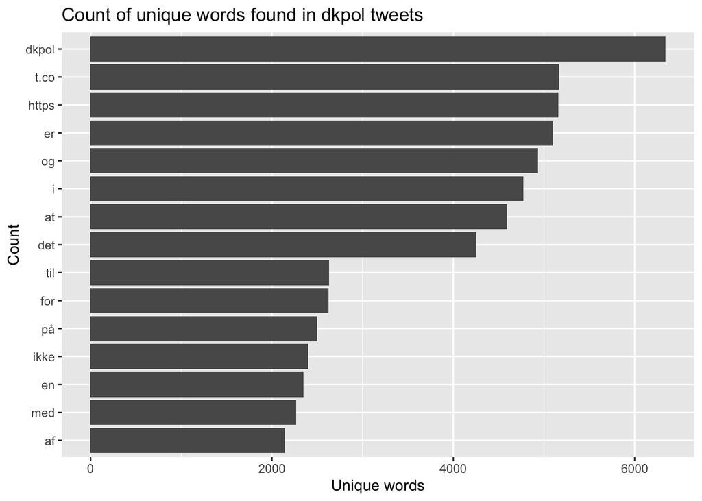

```r
dkpoltweets8_16 %>%
  unnest_tokens(word, text) %>%
  count(word, sort = TRUE) %>%
  top_n(15) %>%
  mutate(word = reorder(word, n)) %>%
  ggplot(aes(x = word, y = n)) +
  geom_col() +
  xlab(NULL) +
  coord_flip() +
      labs(x = "Count",
      y = "Unique words",
      title = "Count of unique words found in dkpol tweets")
```

Okay. There are clearly words in those tweets that arent interesting. Lets clean up our data. First we remove all the links in the tweets:

```r
dkpoltweets8_16_cleaned <- dkpoltweets8_16 %>%
  mutate(text =
           str_remove_all(
                          text,
                          pattern =
                            "https:")) %>%
  mutate(text =
           str_remove_all(
                          text,
                          pattern =
                            "t.co.+"))
```

But what about those stop words like “det”, “den” and “og”? We need to import a danish stop word list.:

```r
stopord <- read_csv("https://gist.githubusercontent.com/maxodsbjerg/f2271ec1a1d76af4b91eaa78cf6f2016/raw/4d1fb3287abbce75d7b18d8147090c952e1652ff/stopord.txt")
```

This list is made specific for this analysis and therefore contain words like (dkpol, will be in every tweet, and dkmedier). By using antijoin we are able to remove all the stop words

# Visualisation of most used words

Lets try the same visualisation again:

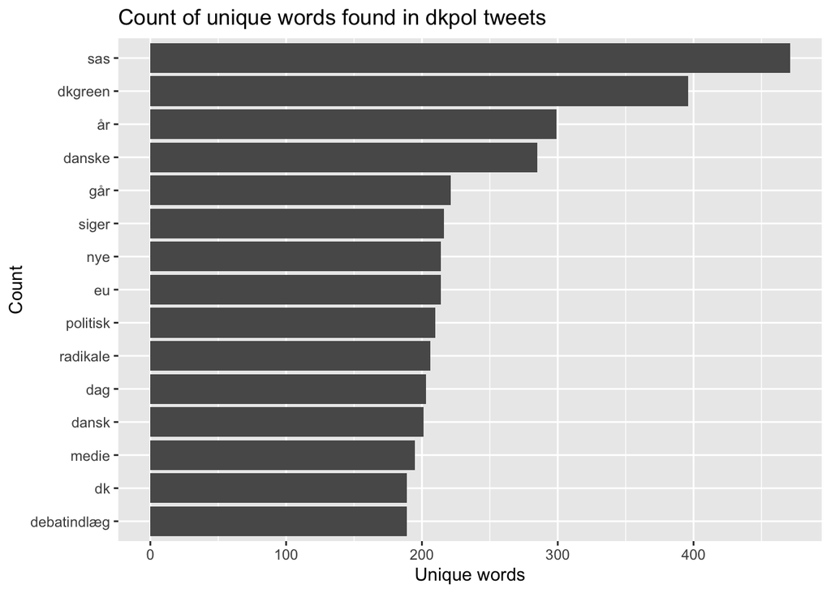

```r
dkpoltweets8_16_cleaned %>%
  unnest_tokens(word, text) %>%
  anti_join(stopord) %>%
  select(word, everything()) %>%
  count(word, sort = TRUE) %>%
  top_n(15) %>%
  mutate(word = reorder(word, n)) %>%
  ggplot(aes(x = word, y = n)) +
  geom_col() +
  xlab(NULL) +
  coord_flip() +
      labs(x = "Count",
      y = "Unique words",
      title = "Count of unique words found in dkpol tweets")
```

```r
dkpoltweets8_16_cleaned %>%
  count(screen_name, sort = TRUE)
```

```
## # A tibble: 1,771 x 2
##    screen_name         n
##    <chr>           <int>
##  1 DanmarksFremtid   258
##  2 liberty_dane      250
##  3 edtwodth          206
##  4 elkjrras          113
##  5 snothvalpen        71
##  6 RhHofs             67
##  7 LundsgaardUffe     54
##  8 gmitchew           51
##  9 bentpn             47
## 10 raesondk           47
## # … with 1,761 more rows
```

Before moving on to the next part of the analysis it is important to notice that we in the next part will examine what distinguises the days in #dkpol from each other. We are therefore impudent ignoring that individual Twitter-users or groups of users can dominate the hashtag’s content on specific days. The above count of who has tweeted the most in the period is to show that there is not a single user holding the majority of the tweets in the period. It it nonetheless worth noting that the users tweeting the most is resposible for 258 tweets out of a total of 6359 tweet, which corresponds to 4,1 % of the total tweets.

# Term frequency - inversed document frequency (tf-idf) - comparing days of tweets to each other

> The statistic tf-idf is intended to measure how important a word is to a document in a collection (or corpus) of documents, for example, to one novel in a collection of novels or to one website in a collection of websites.

-from [*Text Mining with R*](https://www.tidytextmining.com)

In our specific case we are interpretating the total of all tweets in one day as one document.

```r
dkpoltweets8_16_cleaned %>%
  unnest_tokens(word, text) %>%
  count(day, word, sort = TRUE) %>%
  group_by(day) %>%
  summarise(total = sum(n)) -> total_words
total_words
```

```
## # A tibble: 9 x 2
##     day total
##   <int> <int>
## 1     8 16770
## 2     9 16919
## 3    10 20216
## 4    11 23469
## 5    12 27098
## 6    13 28891
## 7    14 24696
## 8    15 14016
## 9    16 17794
```

Next, we need to add the total number of words to our data frame, which is done with `left_join`:

```r
dkpoltweets8_16_cleaned %>%
  unnest_tokens(word, text) %>%
  count(day, word, sort = TRUE) %>%
  left_join(total_words, by = "day") -> dkpol8_16_word_counts
```

Let’s take a quick view of the new data frame:

```r
head(dkpol8_16_word_counts, n=50)
```

```
## # A tibble: 50 x 4
##      day word      n total
##    <int> <chr> <int> <int>
##  1    13 dkpol   898 28891
##  2    12 dkpol   866 27098
##  3    13 er      821 28891
##  4    12 er      774 27098
##  5    13 og      767 28891
##  6    14 dkpol   745 24696
##  7    11 dkpol   734 23469
##  8    13 i       727 28891
##  9    14 er      708 24696
## 10    12 at      682 27098
## # … with 40 more rows
```

$$\textrm{tf}\_\textrm{idf} = \textrm{tf} \times \textrm{idf}$$
,

gives the value of 0 as well.

Next step is to calculate tf and idf for all words:

```r
dkpol8_16_word_counts %>%
  bind_tf_idf(word, day, n) -> dkpol8_16_tfidf

head(dkpol8_16_tfidf, n= 100)
```

```
## # A tibble: 100 x 7
##      day word      n total     tf   idf tf_idf
##    <int> <chr> <int> <int>  <dbl> <dbl>  <dbl>
##  1    13 dkpol   898 28891 0.0311     0      0
##  2    12 dkpol   866 27098 0.0320     0      0
##  3    13 er      821 28891 0.0284     0      0
##  4    12 er      774 27098 0.0286     0      0
##  5    13 og      767 28891 0.0265     0      0
##  6    14 dkpol   745 24696 0.0302     0      0
##  7    11 dkpol   734 23469 0.0313     0      0
##  8    13 i       727 28891 0.0252     0      0
##  9    14 er      708 24696 0.0287     0      0
## 10    12 at      682 27098 0.0252     0      0
## # … with 90 more rows
```

Let’s try with an descending order instead:

```r
dkpol8_16_tfidf <- dkpol8_16_tfidf %>%
  select(-total) %>%
  arrange(desc(tf_idf))

head(dkpol8_16_tfidf, n= 100)
```

```
## # A tibble: 100 x 6
##      day word               n       tf   idf  tf_idf
##    <int> <chr>          <int>    <dbl> <dbl>   <dbl>
##  1    12 sas              228 0.00841  0.405 0.00341
##  2    13 sas              153 0.00530  0.405 0.00215
##  3    14 blommeholm        30 0.00121  1.50  0.00183
##  4    16 larsnp            12 0.000674 2.20  0.00148
##  5    16 nævnet            17 0.000955 1.50  0.00144
##  6    14 stinelinnemann    31 0.00126  1.10  0.00138
##  7    10 strafcelle        11 0.000544 2.20  0.00120
##  8     8 uniform           13 0.000775 1.50  0.00117
##  9    14 besbensen         35 0.00142  0.811 0.00115
## 10    16 24syv             34 0.00191  0.588 0.00112
## # … with 90 more rows
```

# Visualisation of tf-idf

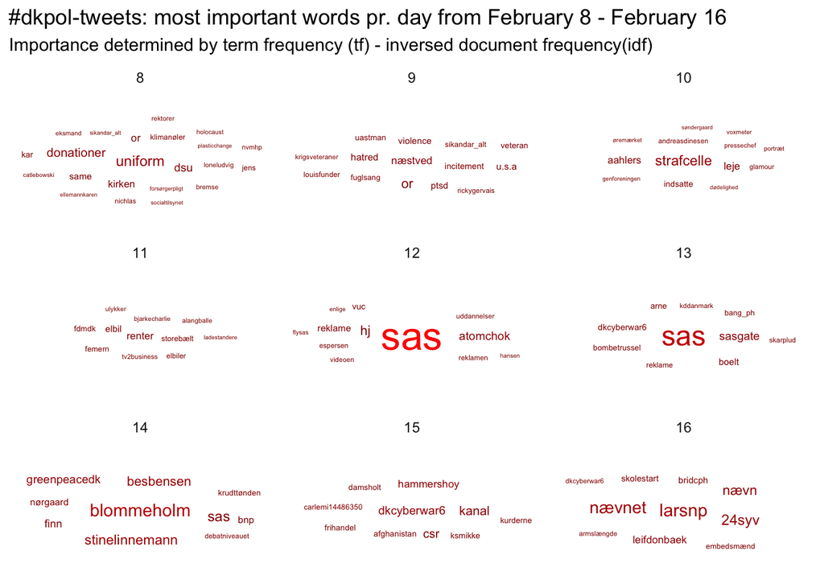

```r
dkpol8_16_tfidf %>%
  arrange(desc(tf_idf)) %>%
  mutate(word = factor(word, levels = rev(unique(word)))) %>%
  group_by(day) %>%
  top_n(10) %>%
  ungroup %>%
  ggplot(aes(label = word, size = tf_idf, color = tf_idf)) +
  geom_text_wordcloud_area() +
  scale_size_area(max_size = 8.5) +
  theme_minimal() +
  facet_wrap(~day, ncol = 3, scales = "free") +
  scale_color_gradient(low = "darkred", high = "red") +
  labs(
      title = "#dkpol-tweets: most important words pr. day from February 8 - February 16",
       subtitle = "Importance determined by term frequency (tf) - inversed document frequency(idf)")
```

```r
ggsave("tfidf_dkpol_wordclouds.pdf", width = 30, height = 20, units = "cm")
ggsave("tfidf_dkpol_wordclouds.png", width = 30, height = 20, units = "cm")
```